# Introduction to ggplot2

# Lesson objectives

This lesson complements the [Data Carpentry lessons](https://datacarpentry.org/R-ecology-lesson/index.html) by providing an earlier introduction to `ggplot2`. The lesson is to be taught after [Starting With Data](https://datacarpentry.org/R-ecology-lesson/02-starting-with-data.html) but before the [Data Manipulation](https://datacarpentry.org/R-ecology-lesson/03-dplyr.html) lesson.

- Identify the basic parts needed to build a graph with `ggplot2`.
  - defining data, aesthetics and geometries for a basic graph.
- Distinguish when to use or not to use `aes()` to change graph’s aesthetics (e.g. colours, shapes).
- Apply overlaying of multiple geometries on the same graph and define aesthetics separately for each.
- Adjust and customise scales and labels in the graph.

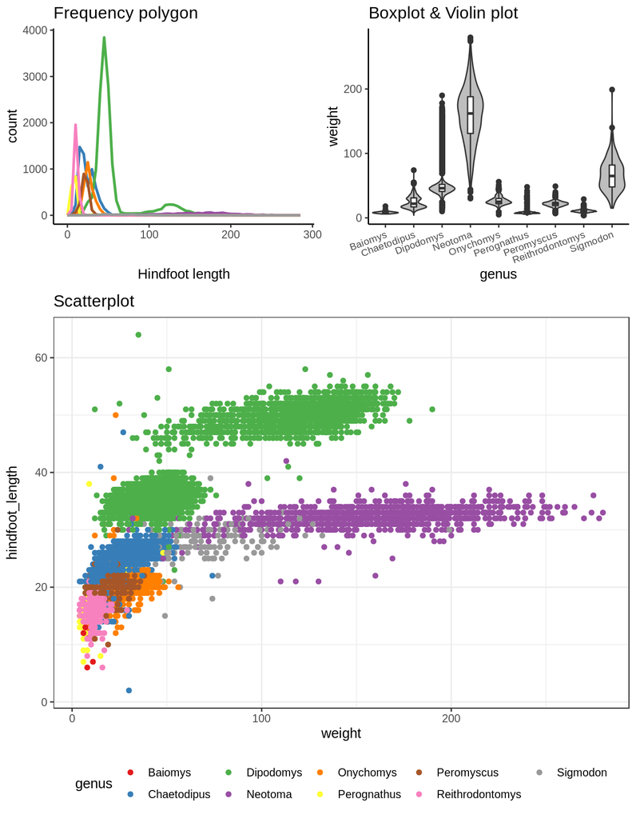

# Setup

Make sure you loaded the `surveys` data:

```r
library(tidyverse)
surveys <- read_csv("data/portal_data_joined.csv")
```

For this lesson we’re going to remove missing values from our table. This is not always desirable (you might be throwing away good data!), but it will help us make this lesson clearer.

We will use the function `drop_na()`, which removes rows with any missing data:

```r
# remove rows with missing data in any of the columns
surveys_nomiss <- drop_na(surveys)
```